# Cyclistic Documentation

Joel Choi

10/6/2021

## Introduction

This document is a documentation on my capstone project Cyclistic. The idea is derived from the Google Data Analytics Certificate course. The project looks at data provided by Divvybikes a bike sharing program based in Chicago. This document will give an in depth look, into the data import, cleaning, analysis, and the visualization steps performed on the data sets. The implementations are based in R.

This is the general structure of the document:

- Introduction
- Ask
- Prepare
- Process
- Analyze
- Act

The Case study looks at a dataset on bike sharing, and aims to help the business to achieve the goals set by the stakeholders. Here, the context and the parties involved are introduced, to set the scene. In order to understand the context it is worth reading, however the analysis and results should be sufficient by themselves to showcase knowledge.

# Characters and teams

**Cyclistic**: A bike-share program that features more than 5,800 bicycles and 600 docking stations. They also offer other types of bikes, making bike-sharing more inclusive to people with disabilities and riders, who cannot use a two-wheeled bike. They offer flexible pricing plans: single-ride passes, full-day passes and annual memberships. Therefore customers can be divided in casual riders and members. Finance analysts have concluded that annual members are much more profitable than casual riders. Therefore the marketing strategies aimes at converting casual riders into annual members.

**Lily Moreno**: The director of marketing, is responsible for the development of campaigns and initiatives to promote the program. She is interested in analyzing the Cyclistic historical bike trip data to identify trends.

**Cyclistic marketing analytics team**: A team of data analysts who are responsible for collecting analyzing, and reporting data that helps guide Cyclistics marketing strategy. In this example, I am a part of the team.

**Cyclistic executive team**: A notoriously detail-oriented executive team will decide whether to approve the recommended marketing program or not.

## Ask

In this phase concise questions are posed to further understand the goals envisioned by the stakeholders and identify business tasks. Here key stakeholders need to be identified and considered in the questioning.

**What is the problem I am trying to solve?**:

Currently most users are leisure users, without an annual subscription. There is potential to secure these users into long-term users. How are we going to get the users to switch their type of subscription? What data is key, to find out what differentiates Casual riders and Annual riders? What kind of data is available? Why would casual riders buy Cyclistic annual memberships? How can we influence digital media to influence casual riders to become members?

**How can my insights drive business decisions?**:

Being able to concisely determine, what sets casual riders and members apart, and how to be able influence them to become members, growth of the company is ensured. Knowing which measures to take, to secure more members, a more profitable system can be established.

# Key tasks

**Identify Business Task**

Identifying what sets casual riders apart from annual members. Establishing ways of influencing casual riders to become annual members.

**Consider Stakeholders**

The primary stakeholders in this project are the Cyclistic Executive Team. They decide, whether the findings of the data analytics process is insightful and convincing and whether to act on it. Moreno is also a stakeholder, as she is responsible for acting upon the recommendations and she encouraged the use of data analytics to establish insights.

**Statement of business task**

Increasing profitability of the business, by introducing data-driven solutions to transform casual riders to annual riders.

## Prepare

In this phase, the datasets provided are inspected based on ethical data analysis practices, bias and credibility, access to the databases and the import of data.

**Where is the data located?**

On the internet site: https://divvy-tripdata.s3.amazonaws.com/index.html. It is data provided by divvy, which is a Bike sharing program located in Chicago. The City is committed to supporting bicycling as an alternative transportation option. As part of that commitment, the City permits making certain Divvy system data owned by the City (“Data”) available to the public.

**Ethical Criteria**

The datasets do not infringe any ethical boundaries, as the data does not contain any personal or other sensitive information.

**Bias & Credibility**

Bias does not exist, as the data sets contain all interactions with bikes. It has not been shortened in any way. Therefore, if we decide to trim the data, we need to ensure, that we do not introduce bias to the data set. The data is credible, as it is already widely used and featured as a credible source in the Google Data Analytics Certificate Program.

# Importing the data

The Datasets from the website are stored in csv files, which contain the data on bike riders in a month. To use the data, first the data needs to be imported and then it needs to be stitched together, for easier usage.

**Importing Packages needed throughout implementation**

For the implementation, some packages are required later on, which will be installed and initialised first.

```r
options(repos=structure(c(CRAN="http://cran.us.r-project.org")))
install.packages("tidyverse")
```

```r
install.packages("ggplot2")
install.packages("janitor")
install.packages("lubridate")
```

[output not shown]

```
##
##  C:\Users\joelc\AppData\Local\Temp\RtmpUV3z7p\downloaded_packages
```

```r
library("tidyverse")
```

```r
library("ggplot2")
library("janitor")
library("lubridate")
library("rmarkdown")
```

After the packages are imported, we need to set the working directory, to the path in which the data sets are located in .

```r
setwd("~/Work/PortfolioProjects/Cyclistic/Datasets")
```

Now we can create data frames for each data set of each month.

```r
Apr_2020 <- read_csv("~/Work/PortfolioProjects/Cyclistic/Datasets/202004.csv")
May_2020 <- read_csv("~/Work/PortfolioProjects/Cyclistic/Datasets/202005.csv")
Jun_2020 <- read_csv("~/Work/PortfolioProjects/Cyclistic/Datasets/202006.csv")
Jul_2020 <- read_csv("~/Work/PortfolioProjects/Cyclistic/Datasets/202007.csv")
Aug_2020 <- read_csv("~/Work/PortfolioProjects/Cyclistic/Datasets/202008.csv")
Sep_2020 <- read_csv("~/Work/PortfolioProjects/Cyclistic/Datasets/202009.csv")
Oct_2020 <- read_csv("~/Work/PortfolioProjects/Cyclistic/Datasets/202010.csv")
Nov_2020 <- read_csv("~/Work/PortfolioProjects/Cyclistic/Datasets/202011.csv")
Dec_2020 <- read_csv("~/Work/PortfolioProjects/Cyclistic/Datasets/202012.csv")
Jan_2021 <- read_csv("~/Work/PortfolioProjects/Cyclistic/Datasets/202101.csv")
Feb_2021 <- read_csv("~/Work/PortfolioProjects/Cyclistic/Datasets/202102.csv")
Mar_2021 <- read_csv("~/Work/PortfolioProjects/Cyclistic/Datasets/202103.csv")
Apr_2021 <- read_csv("~/Work/PortfolioProjects/Cyclistic/Datasets/202104.csv")
May_2021 <- read_csv("~/Work/PortfolioProjects/Cyclistic/Datasets/202105.csv")
Jun_2021 <- read_csv("~/Work/PortfolioProjects/Cyclistic/Datasets/202106.csv")
Jul_2021 <- read_csv("~/Work/PortfolioProjects/Cyclistic/Datasets/202107.csv")
Aug_2021 <- read_csv("~/Work/PortfolioProjects/Cyclistic/Datasets/202108.csv")
Sep_2021 <- read_csv("~/Work/PortfolioProjects/Cyclistic/Datasets/202109.csv")
```

Before we are able to merge the frames to one, we need to make sure, that the types in each column match, so that the merging of data works seamlessly. Overall we are looking for anomalies, which might complicate the stacking of data sets.

```r
colnames(Apr_2020)
```

```
##  [1] "ride_id"            "rideable_type"      "started_at"
##  [4] "ended_at"           "start_station_name" "start_station_id"
##  [7] "end_station_name"   "end_station_id"     "start_lat"
## [10] "start_lng"          "end_lat"            "end_lng"
## [13] "member_casual"
```

```r
colnames(May_2020)
```

```
##  [1] "ride_id"            "rideable_type"      "started_at"
##  [4] "ended_at"           "start_station_name" "start_station_id"
##  [7] "end_station_name"   "end_station_id"     "start_lat"
## [10] "start_lng"          "end_lat"            "end_lng"
## [13] "member_casual"
```

```r
colnames(Jun_2020)
```

```
##  [1] "ride_id"            "rideable_type"      "started_at"
##  [4] "ended_at"           "start_station_name" "start_station_id"
##  [7] "end_station_name"   "end_station_id"     "start_lat"
## [10] "start_lng"          "end_lat"            "end_lng"
## [13] "member_casual"
```

```r
colnames(Jul_2020)
```

```
##  [1] "ride_id"            "rideable_type"      "started_at"
##  [4] "ended_at"           "start_station_name" "start_station_id"
##  [7] "end_station_name"   "end_station_id"     "start_lat"
## [10] "start_lng"          "end_lat"            "end_lng"
## [13] "member_casual"
```

```r
str(Apr_2020)
```

```
## spec_tbl_df [84,776 x 13] (S3: spec_tbl_df/tbl_df/tbl/data.frame)
##  $ ride_id           : chr [1:84776] "A847FADBBC638E45" "5405B80E996FF60D" "5DD24A79A4E006F4" "2A59BBDF5CDBA725" ...
##  $ rideable_type     : chr [1:84776] "docked_bike" "docked_bike" "docked_bike" "docked_bike" ...
##  $ started_at        : POSIXct[1:84776], format: "2020-04-26 17:45:14" "2020-04-17 17:08:54" ...
##  $ ended_at          : POSIXct[1:84776], format: "2020-04-26 18:12:03" "2020-04-17 17:17:03" ...
##  $ start_station_name: chr [1:84776] "Eckhart Park" "Drake Ave & Fullerton Ave" "McClurg Ct & Erie St" "California Ave & Division St" ...
##  $ start_station_id  : num [1:84776] 86 503 142 216 125 173 35 434 627 377 ...
##  $ end_station_name  : chr [1:84776] "Lincoln Ave & Diversey Pkwy" "Kosciuszko Park" "Indiana Ave & Roosevelt Rd" "Wood St & Augusta Blvd" ...
##  $ end_station_id    : num [1:84776] 152 499 255 657 323 35 635 382 359 508 ...
##  $ start_lat         : num [1:84776] 41.9 41.9 41.9 41.9 41.9 ...
##  $ start_lng         : num [1:84776] -87.7 -87.7 -87.6 -87.7 -87.6 ...
##  $ end_lat           : num [1:84776] 41.9 41.9 41.9 41.9 42 ...
##  $ end_lng           : num [1:84776] -87.7 -87.7 -87.6 -87.7 -87.7 ...
##  $ member_casual     : chr [1:84776] "member" "member" "member" "member" ...
##  - attr(*, "spec")=
##   .. cols(
##   ..   ride_id = col_character(),
##   ..   rideable_type = col_character(),
##   ..   started_at = col_datetime(format = ""),
##   ..   ended_at = col_datetime(format = ""),
##   ..   start_station_name = col_character(),
##   ..   start_station_id = col_double(),
##   ..   end_station_name = col_character(),
##   ..   end_station_id = col_double(),
##   ..   start_lat = col_double(),
##   ..   start_lng = col_double(),
##   ..   end_lat = col_double(),
##   ..   end_lng = col_double(),
##   ..   member_casual = col_character()
##   .. )
##  - attr(*, "problems")=<externalptr>
```

```r
str(May_2020)
```

```
## spec_tbl_df [200,274 x 13] (S3: spec_tbl_df/tbl_df/tbl/data.frame)
##  $ ride_id           : chr [1:200274] "02668AD35674B983" "7A50CCAF1EDDB28F" "2FFCDFDB91FE9A52" "58991CF1DB75BA84" ...
##  $ rideable_type     : chr [1:200274] "docked_bike" "docked_bike" "docked_bike" "docked_bike" ...
##  $ started_at        : POSIXct[1:200274], format: "2020-05-27 10:03:52" "2020-05-25 10:47:11" ...
##  $ ended_at          : POSIXct[1:200274], format: "2020-05-27 10:16:49" "2020-05-25 11:05:40" ...
##  $ start_station_name: chr [1:200274] "Franklin St & Jackson Blvd" "Clark St & Wrightwood Ave" "Kedzie Ave & Milwaukee Ave" "Clarendon Ave & Leland Ave" ...
##  $ start_station_id  : num [1:200274] 36 340 260 251 261 206 261 180 331 219 ...
##  $ end_station_name  : chr [1:200274] "Wabash Ave & Grand Ave" "Clark St & Leland Ave" "Kedzie Ave & Milwaukee Ave" "Lake Shore Dr & Wellington Ave" ...
##  $ end_station_id    : num [1:200274] 199 326 260 157 206 22 261 180 300 305 ...
##  $ start_lat         : num [1:200274] 41.9 41.9 41.9 42 41.9 ...
##  $ start_lng         : num [1:200274] -87.6 -87.6 -87.7 -87.7 -87.7 ...
##  $ end_lat           : num [1:200274] 41.9 42 41.9 41.9 41.8 ...
##  $ end_lng           : num [1:200274] -87.6 -87.7 -87.7 -87.6 -87.6 ...
##  $ member_casual     : chr [1:200274] "member" "casual" "casual" "casual" ...
##  - attr(*, "spec")=
##   .. cols(
##   ..   ride_id = col_character(),
##   ..   rideable_type = col_character(),
##   ..   started_at = col_datetime(format = ""),
##   ..   ended_at = col_datetime(format = ""),
##   ..   start_station_name = col_character(),
##   ..   start_station_id = col_double(),
##   ..   end_station_name = col_character(),
##   ..   end_station_id = col_double(),
##   ..   start_lat = col_double(),
##   ..   start_lng = col_double(),
##   ..   end_lat = col_double(),
##   ..   end_lng = col_double(),
##   ..   member_casual = col_character()
##   .. )
##  - attr(*, "problems")=<externalptr>
```

```r
str(Jun_2020)
```

```
## spec_tbl_df [343,005 x 13] (S3: spec_tbl_df/tbl_df/tbl/data.frame)
##  $ ride_id           : chr [1:343005] "8CD5DE2C2B6C4CFC" "9A191EB2C751D85D" "F37D14B0B5659BCF" "C41237B506E85FA1" ...
##  $ rideable_type     : chr [1:343005] "docked_bike" "docked_bike" "docked_bike" "docked_bike" ...
##  $ started_at        : POSIXct[1:343005], format: "2020-06-13 23:24:48" "2020-06-26 07:26:10" ...
##  $ ended_at          : POSIXct[1:343005], format: "2020-06-13 23:36:55" "2020-06-26 07:31:58" ...
##  $ start_station_name: chr [1:343005] "Wilton Ave & Belmont Ave" "Federal St & Polk St" "Daley Center Plaza" "Broadway & Cornelia Ave" ...
##  $ start_station_id  : num [1:343005] 117 41 81 303 327 327 41 115 338 84 ...
##  $ end_station_name  : chr [1:343005] "Damen Ave & Clybourn Ave" "Daley Center Plaza" "State St & Harrison St" "Broadway & Berwyn Ave" ...
##  $ end_station_id    : num [1:343005] 163 81 5 294 117 117 81 303 164 53 ...
##  $ start_lat         : num [1:343005] 41.9 41.9 41.9 41.9 41.9 ...
##  $ start_lng         : num [1:343005] -87.7 -87.6 -87.6 -87.6 -87.7 ...
##  $ end_lat           : num [1:343005] 41.9 41.9 41.9 42 41.9 ...
##  $ end_lng           : num [1:343005] -87.7 -87.6 -87.6 -87.7 -87.7 ...
##  $ member_casual     : chr [1:343005] "casual" "member" "member" "casual" ...
##  - attr(*, "spec")=
##   .. cols(
##   ..   ride_id = col_character(),
##   ..   rideable_type = col_character(),
##   ..   started_at = col_datetime(format = ""),
##   ..   ended_at = col_datetime(format = ""),
##   ..   start_station_name = col_character(),
##   ..   start_station_id = col_double(),
##   ..   end_station_name = col_character(),
##   ..   end_station_id = col_double(),
##   ..   start_lat = col_double(),
##   ..   start_lng = col_double(),
##   ..   end_lat = col_double(),
##   ..   end_lng = col_double(),
##   ..   member_casual = col_character()
##   .. )
##  - attr(*, "problems")=<externalptr>
```

```r
str(Jul_2020)
```

```
## spec_tbl_df [551,480 x 13] (S3: spec_tbl_df/tbl_df/tbl/data.frame)
##  $ ride_id           : chr [1:551480] "762198876D69004D" "BEC9C9FBA0D4CF1B" "D2FD8EA432C77EC1" "54AE594E20B35881" ...
##  $ rideable_type     : chr [1:551480] "docked_bike" "docked_bike" "docked_bike" "docked_bike" ...
##  $ started_at        : POSIXct[1:551480], format: "2020-07-09 15:22:02" "2020-07-24 23:56:30" ...
##  $ ended_at          : POSIXct[1:551480], format: "2020-07-09 15:25:52" "2020-07-25 00:20:17" ...
##  $ start_station_name: chr [1:551480] "Ritchie Ct & Banks St" "Halsted St & Roscoe St" "Lake Shore Dr & Diversey Pkwy" "LaSalle St & Illinois St" ...
##  $ start_station_id  : num [1:551480] 180 299 329 181 268 635 113 211 176 31 ...
##  $ end_station_name  : chr [1:551480] "Wells St & Evergreen Ave" "Broadway & Ridge Ave" "Clark St & Wellington Ave" "Clark St & Armitage Ave" ...
##  $ end_station_id    : num [1:551480] 291 461 156 94 301 289 140 31 191 142 ...
##  $ start_lat         : num [1:551480] 41.9 41.9 41.9 41.9 41.9 ...
##  $ start_lng         : num [1:551480] -87.6 -87.6 -87.6 -87.6 -87.6 ...
##  $ end_lat           : num [1:551480] 41.9 42 41.9 41.9 41.9 ...
##  $ end_lng           : num [1:551480] -87.6 -87.7 -87.6 -87.6 -87.6 ...
##  $ member_casual     : chr [1:551480] "member" "member" "casual" "casual" ...
##  - attr(*, "spec")=
##   .. cols(
##   ..   ride_id = col_character(),
##   ..   rideable_type = col_character(),
##   ..   started_at = col_datetime(format = ""),
##   ..   ended_at = col_datetime(format = ""),
##   ..   start_station_name = col_character(),
##   ..   start_station_id = col_double(),
##   ..   end_station_name = col_character(),
##   ..   end_station_id = col_double(),
##   ..   start_lat = col_double(),
##   ..   start_lng = col_double(),
##   ..   end_lat = col_double(),
##   ..   end_lng = col_double(),
##   ..   member_casual = col_character()
##   .. )
##  - attr(*, "problems")=<externalptr>
```

```r
Apr_2020 <-  mutate(Apr_2020, ride_id = as.character(ride_id)
                    ,rideable_type = as.character(rideable_type))
Jun_2020 <-  mutate(Jun_2020, ride_id = as.character(ride_id)
                    ,rideable_type = as.character(rideable_type))
Jul_2020 <-  mutate(Jul_2020, ride_id = as.character(ride_id)
                    ,rideable_type = as.character(rideable_type))
Aug_2020 <-  mutate(Aug_2020, ride_id = as.character(ride_id)
                    ,rideable_type = as.character(rideable_type))
Sep_2020 <-  mutate(Sep_2020, ride_id = as.character(ride_id)
                    ,rideable_type = as.character(rideable_type))
Oct_2020 <-  mutate(Oct_2020, ride_id = as.character(ride_id)
                    ,rideable_type = as.character(rideable_type))
Nov_2020 <-  mutate(Nov_2020, ride_id = as.character(ride_id)
                    ,rideable_type = as.character(rideable_type))
Dec_2020 <-  mutate(Dec_2020, ride_id = as.character(ride_id)
                    ,rideable_type = as.character(rideable_type))
Jan_2021 <-  mutate(Jan_2021, ride_id = as.character(ride_id)
                    ,rideable_type = as.character(rideable_type))
Feb_2021 <-  mutate(Feb_2021, ride_id = as.character(ride_id)
                    ,rideable_type = as.character(rideable_type))
Mar_2021 <-  mutate(Mar_2021, ride_id = as.character(ride_id)
                    ,rideable_type = as.character(rideable_type))
Apr_2021 <-  mutate(Apr_2021, ride_id = as.character(ride_id)
                    ,rideable_type = as.character(rideable_type))
May_2021 <-  mutate(May_2021, ride_id = as.character(ride_id)
                    ,rideable_type = as.character(rideable_type))
Jun_2021 <-  mutate(Jun_2021, ride_id = as.character(ride_id)
                    ,rideable_type = as.character(rideable_type))
Jul_2021 <-  mutate(Jul_2021, ride_id = as.character(ride_id)
                    ,rideable_type = as.character(rideable_type))
Aug_2021 <-  mutate(Aug_2021, ride_id = as.character(ride_id)
                    ,rideable_type = as.character(rideable_type))
Apr_2020 <-  mutate(Apr_2020,  start_station_id=as.double(start_station_id)
                    ,end_station_id=as.double(end_station_id))
Jun_2020 <-  mutate(Jun_2020, start_station_id=as.double(start_station_id)
                    ,end_station_id=as.double(end_station_id))
Jul_2020 <-  mutate(Jul_2020, start_station_id=as.double(start_station_id)
                    ,end_station_id=as.double(end_station_id))
Aug_2020 <-  mutate(Aug_2020, start_station_id=as.double(start_station_id)
                    ,end_station_id=as.double(end_station_id))
Sep_2020 <-  mutate(Sep_2020, start_station_id=as.double(start_station_id)
                    ,end_station_id=as.double(end_station_id))
Oct_2020 <-  mutate(Oct_2020, start_station_id=as.double(start_station_id)
                    ,end_station_id=as.double(end_station_id))
Nov_2020 <-  mutate(Nov_2020, start_station_id=as.double(start_station_id)
                    ,end_station_id=as.double(end_station_id))
Dec_2020 <-  mutate(Dec_2020, start_station_id=as.double(start_station_id)
                    ,end_station_id=as.double(end_station_id))
Jan_2021 <-  mutate(Jan_2021, start_station_id=as.double(start_station_id)
                    ,end_station_id=as.double(end_station_id))
Feb_2021 <-  mutate(Feb_2021, start_station_id=as.double(start_station_id)
                    ,end_station_id=as.double(end_station_id))
Mar_2021 <-  mutate(Mar_2021, start_station_id=as.double(start_station_id)
                    ,end_station_id=as.double(end_station_id))
Apr_2021 <-  mutate(Apr_2021, start_station_id=as.double(start_station_id)
                    ,end_station_id=as.double(end_station_id))
May_2021 <-  mutate(May_2021, start_station_id=as.double(start_station_id)
                    ,end_station_id=as.double(end_station_id))
Jun_2021 <-  mutate(Jun_2021, start_station_id=as.double(start_station_id)
                    ,end_station_id=as.double(end_station_id))
Jul_2021 <-  mutate(Jul_2021, start_station_id=as.double(start_station_id)
                    ,end_station_id=as.double(end_station_id))
Aug_2021 <-  mutate(Aug_2021, start_station_id=as.double(start_station_id)
                    ,end_station_id=as.double(end_station_id))
```

```r
bike_trips <- rbind(Apr_2020, Jun_2020, Jul_2020, Aug_2020, Sep_2020, Oct_2020,
                    Nov_2020, Dec_2020, Jan_2021, Feb_2021, Mar_2021, Apr_2021,
                    May_2021, Jun_2021, Jul_2021, Aug_2021)
```

The preparation of the data, including the import and the summarization of the data sets to a single data frame is completed. We have confirmed, that the usage is ethical and safe. It is noteworthy, that through filtering bias can be introduced. Therefore, during the data cleaning steps, we need to check whether we introduce bias.

## Processing

In the Processing phase, we begin connecting our business objectives to data analysis. The first step is to identify potentially dirty data. We clean those using various functions in R. The documentation of the data cleaning process is of utmost importance, as later on other users, should be able to retrace the steps taken and judge the correctness.

# Data cleaning

First we begin by looking at some general information about the data frame, in the hopes of identifying problems.

```r
dim(bike_trips)
```

```
## [1] 6514694      13
```

```r
colnames(bike_trips)
```

```
##  [1] "ride_id"            "rideable_type"      "started_at"
##  [4] "ended_at"           "start_station_name" "start_station_id"
##  [7] "end_station_name"   "end_station_id"     "start_lat"
## [10] "start_lng"          "end_lat"            "end_lng"
## [13] "member_casual"
```

```r
str(bike_trips)
```

```
## spec_tbl_df [6,514,694 x 13] (S3: spec_tbl_df/tbl_df/tbl/data.frame)
##  $ ride_id           : chr [1:6514694] "A847FADBBC638E45" "5405B80E996FF60D" "5DD24A79A4E006F4" "2A59BBDF5CDBA725" ...
##  $ rideable_type     : chr [1:6514694] "docked_bike" "docked_bike" "docked_bike" "docked_bike" ...
##  $ started_at        : POSIXct[1:6514694], format: "2020-04-26 17:45:14" "2020-04-17 17:08:54" ...
##  $ ended_at          : POSIXct[1:6514694], format: "2020-04-26 18:12:03" "2020-04-17 17:17:03" ...
##  $ start_station_name: chr [1:6514694] "Eckhart Park" "Drake Ave & Fullerton Ave" "McClurg Ct & Erie St" "California Ave & Division St" ...
##  $ start_station_id  : num [1:6514694] 86 503 142 216 125 173 35 434 627 377 ...
##  $ end_station_name  : chr [1:6514694] "Lincoln Ave & Diversey Pkwy" "Kosciuszko Park" "Indiana Ave & Roosevelt Rd" "Wood St & Augusta Blvd" ...
##  $ end_station_id    : num [1:6514694] 152 499 255 657 323 35 635 382 359 508 ...
##  $ start_lat         : num [1:6514694] 41.9 41.9 41.9 41.9 41.9 ...
##  $ start_lng         : num [1:6514694] -87.7 -87.7 -87.6 -87.7 -87.6 ...
##  $ end_lat           : num [1:6514694] 41.9 41.9 41.9 41.9 42 ...
##  $ end_lng           : num [1:6514694] -87.7 -87.7 -87.6 -87.7 -87.7 ...
##  $ member_casual     : chr [1:6514694] "member" "member" "member" "member" ...
##  - attr(*, "spec")=
##   .. cols(
##   ..   ride_id = col_character(),
##   ..   rideable_type = col_character(),
##   ..   started_at = col_datetime(format = ""),
##   ..   ended_at = col_datetime(format = ""),
##   ..   start_station_name = col_character(),
##   ..   start_station_id = col_double(),
##   ..   end_station_name = col_character(),
##   ..   end_station_id = col_double(),
##   ..   start_lat = col_double(),
##   ..   start_lng = col_double(),
##   ..   end_lat = col_double(),
##   ..   end_lng = col_double(),
##   ..   member_casual = col_character()
##   .. )
##  - attr(*, "problems")=<externalptr>
```

```r
summary(bike_trips)
```

```
##    ride_id          rideable_type        started_at
##  Length:6514694     Length:6514694     Min.   :2020-04-01 00:00:30
##  Class :character   Class :character   1st Qu.:2020-09-02 19:33:45
##  Mode  :character   Mode  :character   Median :2021-03-28 07:07:57
##                                        Mean   :2021-02-04 13:20:08
##                                        3rd Qu.:2021-06-30 21:14:03
##                                        Max.   :2021-08-31 23:59:35
##
##     ended_at                   start_station_name start_station_id
##  Min.   :2020-04-01 00:10:45   Length:6514694     Min.   :     2
##  1st Qu.:2020-09-02 19:56:36   Class :character   1st Qu.:   153
##  Median :2021-03-28 07:48:26   Mode  :character   Median :   324
##  Mean   :2021-02-04 13:44:24                      Mean   :  4601
##  3rd Qu.:2021-06-30 21:38:40                      3rd Qu.: 13058
##  Max.   :2021-09-01 17:37:35                      Max.   :202480
##                                                   NA's   :2316452
##  end_station_name   end_station_id      start_lat       start_lng
##  Length:6514694     Min.   :     2    Min.   :41.64   Min.   :-87.87
##  Class :character   1st Qu.:   153    1st Qu.:41.88   1st Qu.:-87.66
##  Mode  :character   Median :   324    Median :41.90   Median :-87.64
##                     Mean   :  4590    Mean   :41.90   Mean   :-87.64
##                     3rd Qu.: 13058    3rd Qu.:41.93   3rd Qu.:-87.63
##                     Max.   :202480    Max.   :42.08   Max.   :-87.52
##                     NA's   :2347545
##     end_lat         end_lng       member_casual
##  Min.   :41.51   Min.   :-88.07   Length:6514694
##  1st Qu.:41.88   1st Qu.:-87.66   Class :character
##  Median :41.90   Median :-87.64   Mode  :character
##  Mean   :41.90   Mean   :-87.64
##  3rd Qu.:41.93   3rd Qu.:-87.63
##  Max.   :42.16   Max.   :-87.44
##  NA's   :7290    NA's   :7290
```

```r
head(bike_trips)
```

```
## # A tibble: 6 x 13
##   ride_id          rideable_type started_at          ended_at            start_station_n~
##   <chr>            <chr>         <dttm>              <dttm>              <chr>
## 1 A847FADBBC638E45 docked_bike   2020-04-26 17:45:14 2020-04-26 18:12:03 Eckhart Park
## 2 5405B80E996FF60D docked_bike   2020-04-17 17:08:54 2020-04-17 17:17:03 Drake Ave & Ful~
## 3 5DD24A79A4E006F4 docked_bike   2020-04-01 17:54:13 2020-04-01 18:08:36 McClurg Ct & Er~
## 4 2A59BBDF5CDBA725 docked_bike   2020-04-07 12:50:19 2020-04-07 13:02:31 California Ave ~
## 5 27AD306C119C6158 docked_bike   2020-04-18 10:22:59 2020-04-18 11:15:54 Rush St & Hubba~
## 6 356216E875132F61 docked_bike   2020-04-30 17:55:47 2020-04-30 18:01:11 Mies van der Ro~
## # ... with 8 more variables: start_station_id <dbl>, end_station_name <chr>,
## #   end_station_id <dbl>, start_lat <dbl>, start_lng <dbl>, end_lat <dbl>,
## #   end_lng <dbl>, member_casual <chr>
```

In the tests we already identify the existence of multiple NA values and two columns on longitude and latitude. We begin by trimming the data, by removing the two columns storing data on the location. Here, we do not look at these columns, as they do not provide sufficient data to work with during analysis. In the future it might be possible to find the exact location and its surroundings based on the two values, and generate insights from this perspective. However, in this analysis, the data is disregarded.

```r
trips <- bike_trips %>%
  select(-c(start_lat, start_lng, end_lat, end_lng ))
```

Now we look at the total number of casual and annual members.

```r
table(bike_trips$member_casual)
```

```
##
##  casual  member
## 2962392 3552302
```

```r
casual_percentage <- 2962392/(2962392+3552302)*100
casual_percentage
```

```
## [1] 45.47247
```

```r
member_percentage <- 3552302/(2962392+3552302)*100
member_percentage
```

```
## [1] 54.52753
```

Here we derive the percentages of each category. This is the distribution on all entries. With this knowledge we can compare the dataset after trimming, to see whether bias was introduced.

The date is currently saved in a single column. This is not optimal for later use, therefore we split the column to year, month, day, day of week

```r
trips$date <- as.Date(trips$started_at) #The default format is yyyy-mm-dd
trips$month <- format(as.Date(trips$date), "%m")
trips$day <- format(as.Date(trips$date), "%d")
trips$year <- format(as.Date(trips$date), "%Y")
trips$day_of_week <- format(as.Date(trips$date), "%A")
```

We also create a column for the ride duration, as currently we have a start time and an end time. A single column to display the duration is favorable.

```r
trips$ride_length <- difftime(trips$ended_at,trips$started_at)
min_ride <- min(trips$ride_length)
```

Although, when we look at the minimum of the column, a negative value is returned, however durations should not be negative. Upon closer inspection, some end times are earlier than start times. Therefore, we trim all entries, where this problem occurs.

```r
trips <- trips[trips$ride_length > 0, ]
min_ride <- min(trips$ride_length)
```

Now, the minimum is one second and all negative values were removed. Next we get rid of all rows with NA values.

```r
nrow(trips)
```

```
## [1] 6503593
```

```r
trips <- trips[complete.cases(trips), ]
nrow(trips)
```

```
## [1] 3363184
```

By checking the total amount of rows before and after trimming, we realize, that about half of the rows where removed. Still, we have more than 3 million rows of clean data, which is more than enough to perform accurate data analysis. However, we need to make sure that through trimming, bias has not been introduced. We do this by finding the percentage of user types of the new data set and comparing it to the original one.

```r
table(trips['member_casual'])
```

```
##
##  casual  member
## 1519119 1844065
```

```r
clean_casual_percentage <- 1519119/(1519119+1844065)*100
clean_casual_percentage
```

```
## [1] 45.16907
```

```r
clean_member_percentage <- 1844065/(1519119+1844065)*100
clean_member_percentage
```

```
## [1] 54.83093
```

We see, that the percentage has changed less than 0.4% which is a neglible difference. Therefore we can safely assume, that trimming the dataset has not introduced any sort of bias.

Now that the data is clean and ready to use, we continue to the analysis phase.

## Analysis

During the analysis phase we inspect the data frame and look for trends, patterns, anomalies or other interesting factors, by sorting, filtering lists. Usually, during analysis, the collaboration with analysis team members is performed, but as I am doing this project by myself, this part is skipped. Alongside the analysis, visualizations are created to show the data more clearly.

First we create a pie chart containing casual riders and annual members, to get an overview on how the current situation is.

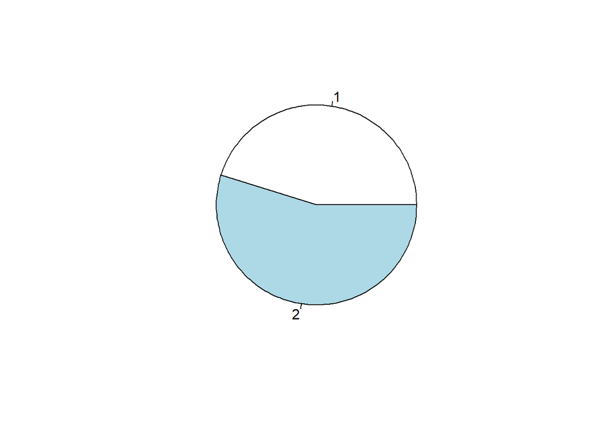

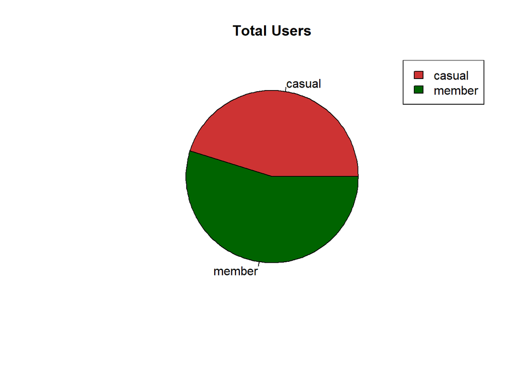

Currently, there are more members than casual riders, however the difference is not substantial. Still from this diagram we can advise the stakeholders to also appeal to the current members, to keep them subscribed to the program, as they occupy the majority of bike rides.

Now we need to establish the differences between casual riders and annual users as stated in the business task. First we observe the differences when it comes to ride duration. We fist assess different measures on the ride duration for casual riders and members.

```r
mean_length <- aggregate(trips$ride_length ~ trips$member_casual, FUN = mean)
median_length <- aggregate(trips$ride_length ~ trips$member_casual, FUN = median)
max_length <- aggregate(trips$ride_length ~ trips$member_casual, FUN = max)
min_length <-aggregate(trips$ride_length ~ trips$member_casual, FUN = min)
```

Next we create a bar chart comparing the average duration of rides depending on the weekdays. We need to first order the day of the weeks, so that the days are displayed in the correct order.

```
## # A tibble: 3,363,184 x 15
##    ride_id          rideable_type started_at          ended_at
##    <chr>            <chr>         <dttm>              <dttm>
##  1 A847FADBBC638E45 docked_bike   2020-04-26 17:45:14 2020-04-26 18:12:03
##  2 AA1C8D93190BB6A9 docked_bike   2020-04-19 13:39:57 2020-04-19 14:01:39
##  3 042511EE70500A4A docked_bike   2020-04-05 15:39:52 2020-04-05 16:15:51
##  4 B5BBCA72F5A8BE3C docked_bike   2020-04-05 14:29:39 2020-04-05 14:44:30
##  5 E65BB1A0FBE1A613 docked_bike   2020-04-05 13:44:17 2020-04-05 13:58:12
##  6 3CAE42BE39E1C534 docked_bike   2020-04-12 12:50:11 2020-04-12 13:24:25
##  7 09184B97ED4833F5 docked_bike   2020-04-12 08:44:05 2020-04-12 08:59:37
##  8 830D7D41EA1ACBE3 docked_bike   2020-04-05 18:49:42 2020-04-05 19:08:01
##  9 FAC33D188B0117C8 docked_bike   2020-04-05 20:06:27 2020-04-05 20:18:18
## 10 3D97CF5100E0F5B0 docked_bike   2020-04-26 18:42:24 2020-04-26 18:48:06
## # ... with 3,363,174 more rows, and 11 more variables:
## #   start_station_name <chr>, start_station_id <dbl>, end_station_name <chr>,
## #   end_station_id <dbl>, member_casual <chr>, date <date>, month <chr>,
## #   day <chr>, year <chr>, day_of_week <fct>, ride_length <drtn>
```

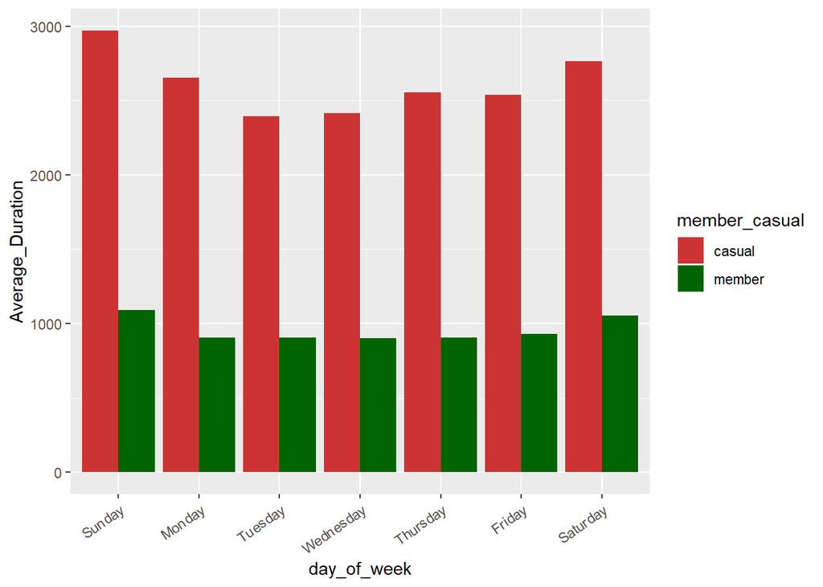

From this graph we can again observe the general longer use of casual riders. We also observe, that Sunday is the day with longest rides on average, followed by Saturday and Monday.

After having looked at the ride duration we now take a look at number of rides according to the day of the week.

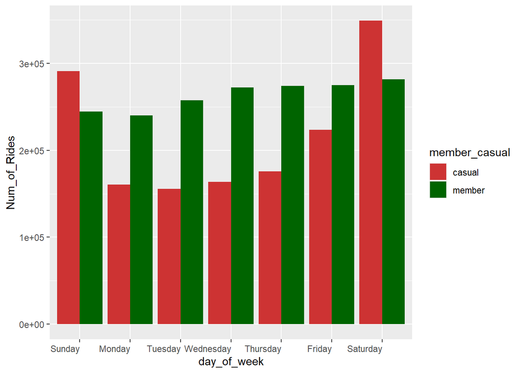

In this graph, the differences between casual riders and members becomes more apparent. Whilst members use the service at a relatively similar level, with a slight dip on Sundays and Mondays, casual riders use the service on weekends a lot more than on other days. This lets us to believe, that casual riders use the bikes for enjoyment rather than for purely transportation purposes.

Next we want to observe the trends when it comes to seasons. First we create the new column season and then we create the bar chart.

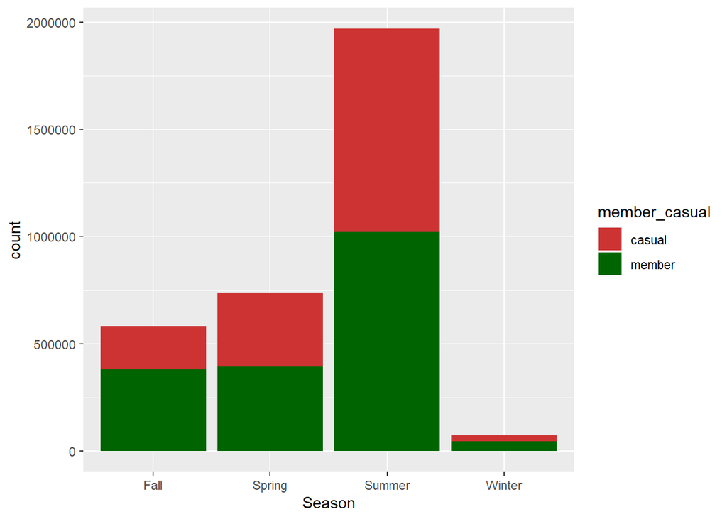

The Visualization illustrates that the use of the bike services is similar for both types of users. Summer is by far the season with the most usage, whilst in Winter the service is barely used.

Lastly, we create a graph comparing the usage of the different types of rides.

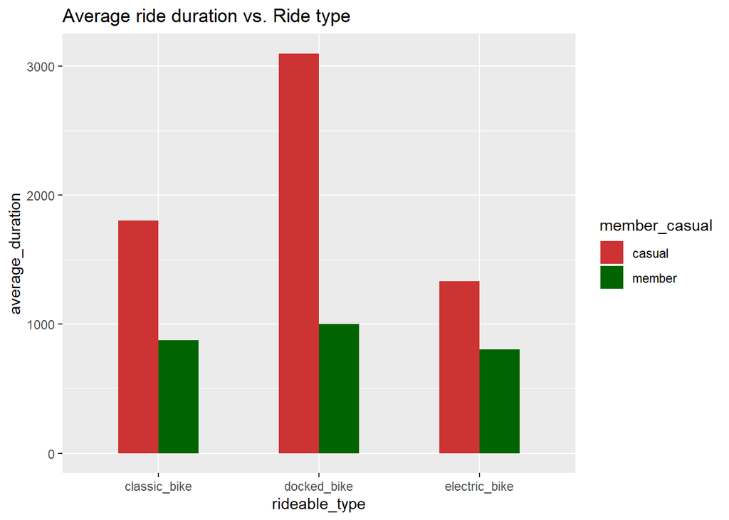

This concludes the analysis done on the data set.

## Act

Having analysed the data set and drawn out several insights, we are now ready to summarise our findings and make a data based recommendation for the stakeholders to consider.

Now we are in a position to make appropriate recommendations, to make data-driven decisions.

First, it is important to note that the business task of targeting casual riders to convert to members is a valid approach, as data shows, that they make up a considerable part of all rides. However, it is also important to appeal to current members to discourage them from unsubscribing.

When it comes to the distribution of marketing resources, we should focus most of it advertising in the Summer season, as most casual users use the service then. This could be an ad on various social media platforms, that illustrate the benefits of a subscription.

In winter it is important to discourage people from unsubscribing from the service. A potential solution would be to offer new and existing members discounts in Winter, or even the option to be able to pause the subscription in winter. Of course the business administration would have to assess the possibilities.

During weekdays, the usage of the service is considerably lower with casual users. An ad campaign showing various advantages of riding bikes for their commute, e.g. positive impact on environment, physical workout, not having to hassle with finding parking spots in the city and much more. This could impact the casual users to also consider using the services for their commute and more often during weekdays, which then would encourage them to book a subscription. Introducing a subscription plan only for using the bikes on weekends could provide a middle ground for undecided casual users. Here, it is however important to assess the risk of losing permanent members who switch to the newly introduced weekend subscription plan. For now, members ride the bikes consistently throughout the week without as much of a spike on weekends. This leads us to believe, that members ride the bike for their every day commute. This would mean the changing of subscriptions is not as likely. More data and analytics is required, to assess whether members would consider changing to that plan. For now, members ride the bikes consistently throughout the week without as much of a spike on weekends. This leads us to believe, that members ride the bike for their every day commute. This would mean the changing of subscriptions is not as likely.